# *Ophiocoma* Photoreceptor Measurements

John D. Kirwan

2019-05-21

```r
library(readr)
library(circular)
library(dplyr)
library(ggplot2)
```

```r
PRC <- read_delim('Ophiocoma_receptor_data.txt',delim = "\t")
```

Modify so that if the direction is right, 180 gets siubtracted from each Image number. Image number is now a proxy for the angle of rotation around the central proximal-distal axis of the receptor.

```r
make_deg <- function(nums){circular(
  nums, type = "angles", units = "degrees", zero = pi, rotation = "clock")}
make_rad <- function(nums){circular(
  pi*nums/180, type = "angles", units = "radians", zero = pi, rotation = "clock")}

PRC %>% mutate(Rotation = make_rad(Image_number)) -> PRC
```

```r
PRC %>%
  arrange(Photoreceptor_cell,Direction,Image_number) -> PRC
```

Get the longitude and latitude positions of the points on the circle surface.

```r
PRC %>%
    mutate(latitude  = ifelse(
      Direction == "Right",  round(Angle * cos(Rotation),digits=2),
                            -round(Angle * cos(Rotation),digits=2)))  %>%
    mutate(longitude = ifelse(
      Direction == "Right",  round(Angle * sin(Rotation),digits=2),
                             round(360 - Angle * sin(Rotation),digits=2))) -> PRC
```

Get widest combined angle for each receptor.

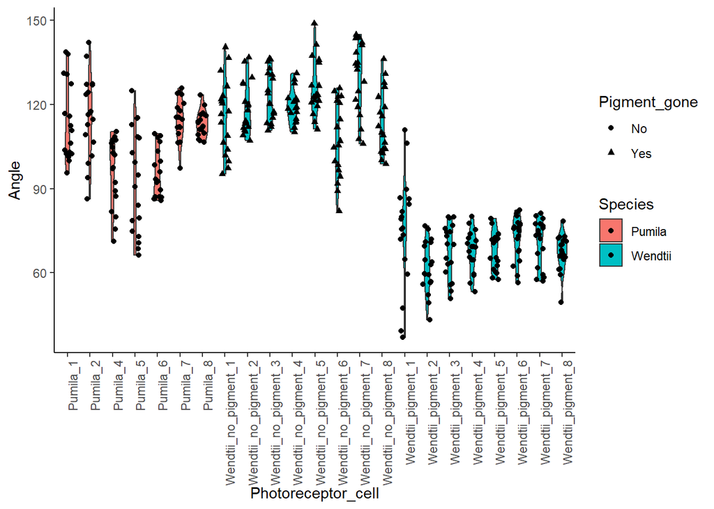

```r
PRC %>%
  filter(is.na(Angle) == F) %>% # removes rows with no angle
  group_by(Species, Pigment_gone, Photoreceptor_cell, Image_number) %>%
    summarize(Angle = sum(Angle)
          ) -> PRC_combined

PRC_combined %>%
  mutate(del_rho = Angle * 0.4571) %>%
  mutate(V_co = 1 / del_rho) -> PRC_combined

PRC_combined %>%
  group_by(Species, Pigment_gone) %>%
    ggplot(aes(Photoreceptor_cell,Angle,fill=Species,shape=Pigment_gone)) +
    geom_violin(width=0.5) + geom_jitter(width = 0.2) +
      theme_classic() + theme(axis.text.x = element_text(angle = 90, hjust = 1))
```

The *O. wendtii* angular apertures widen when the pigment is removed.

where 0 is the angular aperture, and the constant 0.4571 represents the ratio between the half-width of a Gaussian density and the bounds comprising 0.99 of the density (approximating the total angular aperture).

The summed angles for left and right are not the same as those that you have in the spreadsheet. Here are the summary stats.

```r
PRC_combined %>%
  group_by(Species, Pigment_gone, Photoreceptor_cell) %>%
    summarize(
      widest    = max(Angle),
      narrowest = min(Angle),
      mean      = mean(Angle),
      sd        = sd(Angle),
   max_del_rho  = max(del_rho),
   min_del_rho  = min(del_rho),
   mean_del_rho = mean(del_rho),
   med_del_rho  = median(del_rho),
    sd_del_rho  = sd(del_rho)
  ) -> Apertures
print(Apertures)
```

```
## # A tibble: 23 x 12
## # Groups:   Species, Pigment_gone [3]
##    Species Pigment_gone Photoreceptor_c~ widest narrowest  mean    sd
##    <chr>   <chr>        <chr>             <dbl>     <dbl> <dbl> <dbl>
##  1 Pumila  No           Pumila_1          139.       95.6 113.  14.0
##  2 Pumila  No           Pumila_2          142.       86.3 116.  14.6
##  3 Pumila  No           Pumila_4          110.       71.1  95.7 12.3
##  4 Pumila  No           Pumila_5          125.       66.2  92.6 18.8
##  5 Pumila  No           Pumila_6          110.       85.8  95.4  8.71
##  6 Pumila  No           Pumila_7          126.       97.4 115.   7.49
##  7 Pumila  No           Pumila_8          123.      107.  113.   4.50
##  8 Wendtii No           Wendtii_pigment~  111.       37.0  75.0 19.9
##  9 Wendtii No           Wendtii_pigment~   76.8      43.1  62.1  9.25
## 10 Wendtii No           Wendtii_pigment~   79.9      50.8  67.9  9.66
## # ... with 13 more rows, and 5 more variables: max_del_rho <dbl>,
## #   min_del_rho <dbl>, mean_del_rho <dbl>, med_del_rho <dbl>,
## #   sd_del_rho <dbl>
```

Below is a summary of the photoreceptor data, with the left and right angles combined.

```r
PRC_combined %>%
  group_by(Species,Pigment_gone) %>%
           summarize_at(vars(Angle:del_rho),list(mean=mean,sd=sd,max=max,min=min),na.rm = TRUE
           ) -> Spp_PRC_summary

print(Spp_PRC_summary)
```

```
## # A tibble: 3 x 10
## # Groups:   Species [2]
##   Species Pigment_gone Angle_mean del_rho_mean Angle_sd del_rho_sd
##   <chr>   <chr>             <dbl>        <dbl>    <dbl>      <dbl>
## 1 Pumila  No                106.          48.4     15.6       7.11
## 2 Wendtii No                 68.8         31.5     10.7       4.89
## 3 Wendtii Yes               119.          54.5     12.6       5.74
## # ... with 4 more variables: Angle_max <dbl>, del_rho_max <dbl>,
## #   Angle_min <dbl>, del_rho_min <dbl>
```